# Session 4: Introduction to Structural Equation Models

From separate regressions to causal pathways

Oscar Rodriguez de Rivera | University of Exeter

```r
library(tidyverse)
library(lavaan)

theme_set(theme_minimal(base_size = 12))

# Optional for path diagrams:
# install.packages("semPlot")
```

# 1 Session overview

## 1.1 Where this document fits

In earlier sessions, most models had one response variable.

For example, in a regression model we might ask:

> Does temperature explain bird abundance?

or:

> Does vegetation cover explain insect abundance?

These are useful questions, but ecological systems are often more connected than this.

Structural equation models, or **SEMs**, allow us to represent a **network of relationships**. Instead of fitting one isolated regression, we can fit several linked regression equations at the same time.

SEM is useful when we want to ask questions such as:

- Does climate affect biodiversity directly, indirectly, or both?
- Is the effect of land use mediated by vegetation structure?
- Are several measured variables indicators of a latent process?
- Which hypothesised pathway structure is consistent with the data?

## 1.2 Main idea

SEM is based on a path diagram.

A path diagram uses arrows to represent hypothesised relationships.

For example:

```
## Rainfall → Vegetation → Insects → Birds
```

This diagram represents a possible ecological pathway:

- rainfall affects vegetation;
- vegetation affects insects;
- insects affect birds.

The important point is that SEM lets us estimate **direct effects**, **indirect effects** and **total effects**.

## 1.3 Learning outcomes

By the end of this document, students should be able to:

1. explain what a structural equation model is;
2. distinguish direct, indirect and total effects;
3. write a simple path model;
4. fit a SEM using `lavaan`;
5. interpret standardised path coefficients;
6. understand basic model fit measures;
7. connect SEM to regression models used earlier in the course;
8. recognise the difference between path analysis and latent-variable SEM.

# 2 Important caution

## 2.1 SEM does not prove causality automatically

SEM is often presented using causal arrows. However, the software does not magically prove causality.

A path from (X) to (Y) should only be interpreted causally if the scientific design and assumptions support that interpretation.

Causal interpretation depends on:

- a defensible ecological or scientific hypothesis;
- appropriate temporal ordering;
- measured confounders;
- study design;
- model assumptions;
- biological plausibility.

SEM helps us test whether the data are consistent with a hypothesised causal structure.

It does not tell us whether the hypothesised structure is the only possible explanation.

## 2.2 IMPORTANT

> SEM tests whether the data are consistent with a proposed pathway model; it does not prove that the pathway model is true.

# 3 Direct, indirect and total effects

## 3.1 Direct effects

A **direct effect** is represented by one arrow from one variable to another.

For example:

$$\text{Vegetation} \rightarrow \text{Birds}$$

This means vegetation is hypothesised to affect bird abundance directly.

## 3.2 Indirect effects

An **indirect effect** occurs when one variable affects another through an intermediate variable.

For example:

$$\text{Vegetation} \rightarrow \text{Insects} \rightarrow \text{Birds}$$

Here, vegetation may affect birds indirectly because vegetation affects insects, and insects affect birds.

## 3.3 Total effects

The **total effect** is the sum of all direct and indirect effects.

For example, if vegetation affects birds directly and also indirectly through insects, then:

$$\text{Total effect} =
\text{direct effect} +
\text{indirect effect}$$

This is one reason SEM is useful. It allows us to decompose effects into pathways.

# 4 Simulating an ecological pathway model

## 4.1 Ecological story

Imagine a system where:

- temperature and rainfall influence vegetation;
- vegetation influences insect abundance;
- insects influence bird abundance;
- vegetation may also directly affect birds by providing habitat structure;
- temperature may also have a direct effect on birds.

This is a simplified ecological pathway model.

```r
set.seed(456)

n <- 250

sem_dat <- tibble(
  temperature = rnorm(n, mean = 0, sd = 1),
  rainfall = rnorm(n, mean = 0, sd = 1)
) %>%
  mutate(
    vegetation = 0.6 * rainfall - 0.3 * temperature + rnorm(n, sd = 0.7),
    insects = 0.7 * vegetation + 0.2 * temperature + rnorm(n, sd = 0.7),
    birds = 0.6 * insects + 0.3 * vegetation - 0.1 * temperature + rnorm(n, sd = 0.8)
  )

glimpse(sem_dat)
```

```
## Rows: 250
## Columns: 5
## $ temperature <dbl> -1.34352141, 0.62177555, 0.80087466, -1.38889241, -0.71435…
## $ rainfall    <dbl> -0.24991350, 0.07130598, 0.25006436, -1.22892504, -0.05864…
## $ vegetation  <dbl> 0.3548112, -0.4110221, -0.4837993, 0.5678701, -0.6738381, …
## $ insects     <dbl> -0.07658382, -0.01306550, -1.35083212, 0.87634649, 0.03971…
## $ birds       <dbl> 0.06819333, -0.17827233, -0.63712936, -0.50515224, 2.29565…
```

## 4.2 Inspect variable distributions

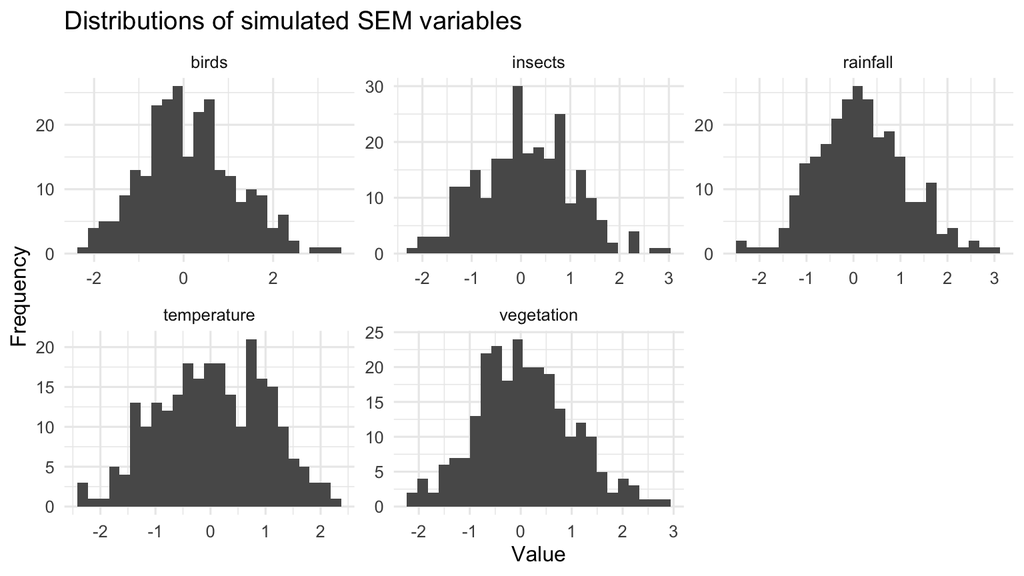

```r
sem_dat %>%
  pivot_longer(
    cols = everything(),
    names_to = "variable",
    values_to = "value"
  ) %>%
  ggplot(aes(x = value)) +
  geom_histogram(bins = 25) +
  facet_wrap(~ variable, scales = "free") +
  labs(
    title = "Distributions of simulated SEM variables",
    x = "Value",
    y = "Frequency"
  )
```

These variables are simulated to be approximately continuous and suitable for a simple path analysis.

In real ecological data, variables may be counts, proportions, ordinal scores or non-normal measurements. That is one reason piecewise SEM can be useful in ecology.

## 4.3 Pairwise relationships

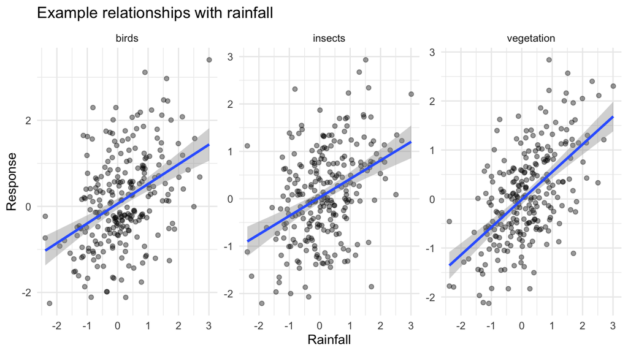

```r
sem_dat %>%
  pivot_longer(
    cols = c(vegetation, insects, birds),
    names_to = "response",
    values_to = "response_value"
  ) %>%
  ggplot(aes(x = rainfall, y = response_value)) +
  geom_point(alpha = 0.4) +
  geom_smooth(method = "lm", se = TRUE) +
  facet_wrap(~ response, scales = "free_y") +
  labs(
    title = "Example relationships with rainfall",
    x = "Rainfall",
    y = "Response"
  )
```

These plots are exploratory. SEM goes further by combining multiple relationships into a single pathway model.

# 5 Writing the SEM model

## 5.1 lavaan syntax

In `lavaan`, regressions are written using `~`.

For example:

```r
insects ~ vegetation
```

means:

> insects are modelled as a function of vegetation.

We can write several regression equations inside one model string.

## 5.2 Path model

```r
path_model <- '
  vegetation ~ a1 * rainfall + a2 * temperature
  insects    ~ b1 * vegetation + b2 * temperature
  birds      ~ c1 * insects + c2 * vegetation + c3 * temperature

  indirect_rainfall_birds := a1 * b1 * c1 + a1 * c2
  total_temperature_birds := c3 + b2 * c1 + a2 * c2 + a2 * b1 * c1
'
```

## 5.3 What do the labels mean?

The labels `a1`, `a2`, `b1`, `b2`, `c1`, `c2` and `c3` name specific path coefficients.

For example:

- `a1` is the path from rainfall to vegetation;
- `b1` is the path from vegetation to insects;
- `c1` is the path from insects to birds;
- `c2` is the direct path from vegetation to birds;
- `c3` is the direct path from temperature to birds.

Naming coefficients allows us to define indirect and total effects.

## 5.4 Indirect rainfall effect on birds

Rainfall can affect birds through two pathways:

1. rainfall → vegetation → birds;
2. rainfall → vegetation → insects → birds.

Therefore, the indirect effect of rainfall on birds is:

$$(a_1 \times c_2) + (a_1 \times b_1 \times c_1)$$

In the `lavaan` syntax, we write:

```r
indirect_rainfall_birds := a1 * b1 * c1 + a1 * c2
```

The operator `:=` defines a new parameter based on existing parameters.

# 6 Fitting the path model

## 6.1 Fit the SEM

```r
path_fit <- lavaan::sem(
  model = path_model,
  data = sem_dat,
  meanstructure = TRUE
)

summary(
  path_fit,
  standardized = TRUE,
  fit.measures = TRUE,
  rsquare = TRUE
)
```

```
## lavaan 0.6-21 ended normally after 1 iteration
##
##   Estimator                                         ML
##   Optimization method                           NLMINB
##   Number of model parameters                        13
##
##   Number of observations                           250
##
## Model Test User Model:
##
##   Test statistic                                 3.501
##   Degrees of freedom                                 2
##   P-value (Chi-square)                           0.174
##
## Model Test Baseline Model:
##
##   Test statistic                               511.037
##   Degrees of freedom                                 9
##   P-value                                        0.000
##
## User Model versus Baseline Model:
##
##   Comparative Fit Index (CFI)                    0.997
##   Tucker-Lewis Index (TLI)                       0.987
##
## Loglikelihood and Information Criteria:
##
##   Loglikelihood user model (H0)               -798.817
##   Loglikelihood unrestricted model (H1)       -797.066
##
##   Akaike (AIC)                                1623.634
##   Bayesian (BIC)                              1669.413
##   Sample-size adjusted Bayesian (SABIC)       1628.202
##
## Root Mean Square Error of Approximation:
##
##   RMSEA                                          0.055
##   90 Percent confidence interval - lower         0.000
##   90 Percent confidence interval - upper         0.148
##   P-value H_0: RMSEA <= 0.050                    0.354
```

[output cut: 32 more lines]

```
##                    Estimate  Std.Err  z-value  P(>|z|)   Std.lv  Std.all
##    .vegetation        0.463    0.041   11.180    0.000    0.463    0.523
##    .insects           0.482    0.043   11.180    0.000    0.482    0.527
##    .birds             0.536    0.048   11.180    0.000    0.536    0.476
##
## R-Square:
##                    Estimate
##     vegetation        0.477
##     insects           0.473
##     birds             0.524
##
## Defined Parameters:
##                    Estimate  Std.Err  z-value  P(>|z|)   Std.lv  Std.all
##     indrct_rnfll_b    0.436    0.048    9.064    0.000    0.436    0.393
##     ttl_tmprtr_brd   -0.171    0.062   -2.749    0.006   -0.171   -0.158
```

## 6.2 What to look for in the output

The output contains several useful parts:

1. **Path coefficients** These estimate the strength and direction of each relationship.
2. **Standardised coefficients** These put effects on a comparable scale.
3. **Defined parameters** These include indirect and total effects.
4. **Fit measures** These summarise how well the model-implied covariance structure matches the observed covariance structure.
5. **R-squared values** These show how much variation is explained in each endogenous variable.

An **endogenous variable** is a variable that appears as a response somewhere in the SEM.

In this model, vegetation, insects and birds are endogenous variables.

# 7 Graphical model

## 7.1 Path diagram

A graphical model is often the clearest way to communicate the SEM structure.

The chunk below draws the fitted path diagram with standardised coefficients if the `semPlot` package is available.

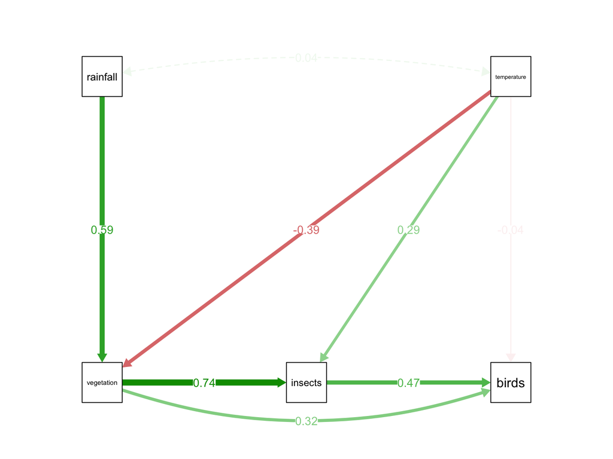

```r
if (requireNamespace("semPlot", quietly = TRUE)) {
  semPlot::semPaths(
    object = path_fit,
    what = "std",
    whatLabels = "std",
    layout = "tree",
    style = "ram",
    residuals = FALSE,
    intercepts = FALSE,
    edge.label.cex = 0.9,
    sizeMan = 7,
    nCharNodes = 0
  )
} else {
  cat("Install the 'semPlot' package to display the graphical model.\n")
}
```

## 7.2 Interpreting the path diagram

The arrows represent the hypothesised pathways.

The numbers on the arrows are standardised coefficients.

A positive coefficient means that higher values of the predictor are associated with higher values of the response, holding other variables in that equation constant.

A negative coefficient means that higher values of the predictor are associated with lower values of the response, holding other variables in that equation constant.

The larger the absolute value, the stronger the standardised association.

# 8 Extracting standardised coefficients

## 8.1 Standardised paths

```r
standardized_paths <- lavaan::standardizedSolution(path_fit) %>%
  as_tibble() %>%
  dplyr::filter(op %in% c("~", ":=")) %>%
  dplyr::select(lhs, op, rhs, est.std, pvalue)

standardized_paths
```

| lhs | op | rhs | est.std | pvalue |
| --- | --- | --- | --- | --- |
| vegetation | ~ | rainfall | 0.58948889 | 0.000000e+00 |
| vegetation | ~ | temperature | -0.38522491 | 0.000000e+00 |
| insects | ~ | vegetation | 0.73682153 | 0.000000e+00 |
| insects | ~ | temperature | 0.28638885 | 1.401647e-09 |
| birds | ~ | insects | 0.47150398 | 2.220446e-16 |
| birds | ~ | vegetation | 0.31916840 | 4.320134e-07 |
| birds | ~ | temperature | -0.03631614 | 4.661494e-01 |
| indirect_rainfall_birds | := | a1*b1*c1+a1*c2 | 0.39294309 | 0.000000e+00 |
| total_temperature_birds | := | c3+b2*c1+a2*c2+a2*b1*c1 | -0.15806691 | 5.130328e-03 |

## 8.2 Interpretation

Rows with `op == "~"` are regression paths.

Rows with `op == ":="` are defined effects, such as indirect or total effects.

The column `est.std` gives the standardised estimate.

The column `pvalue` gives evidence against the null hypothesis that the parameter is zero.

P-values should be interpreted carefully. In SEM, scientific interpretation and model structure are just as important as statistical significance.

# 9 Visualising fitted relationships

## 9.1 Vegetation to insects

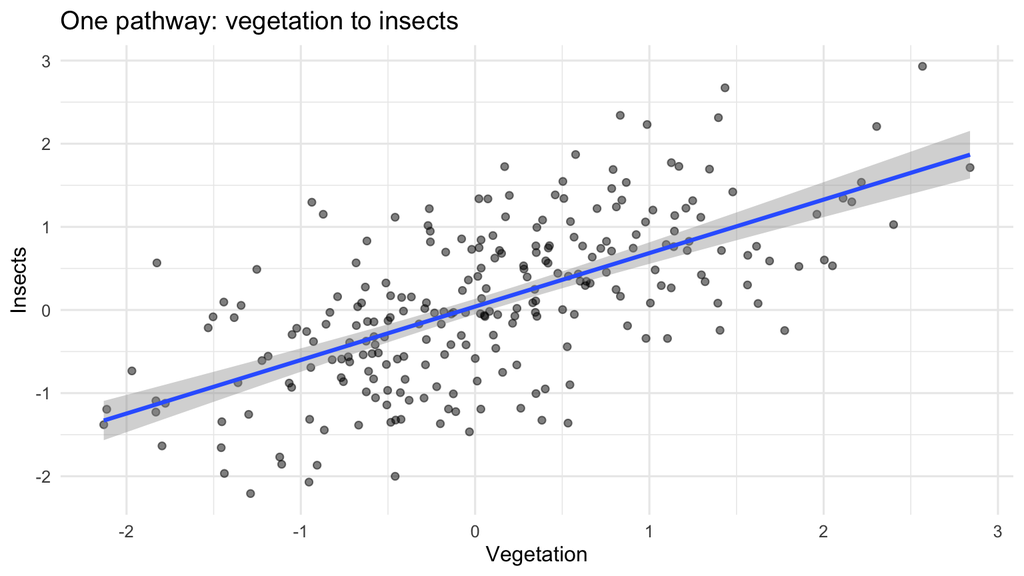

```r
ggplot(sem_dat, aes(x = vegetation, y = insects)) +
  geom_point(alpha = 0.5) +
  geom_smooth(method = "lm", se = TRUE) +
  labs(
    x = "Vegetation",
    y = "Insects",
    title = "One pathway: vegetation to insects"
  )
```

## 9.2 Insects to birds

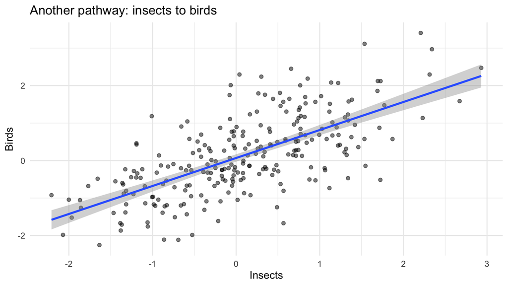

```r
ggplot(sem_dat, aes(x = insects, y = birds)) +
  geom_point(alpha = 0.5) +
  geom_smooth(method = "lm", se = TRUE) +
  labs(
    x = "Insects",
    y = "Birds",
    title = "Another pathway: insects to birds"
  )
```

These plots show individual pathways, but SEM estimates all specified pathways together.

# 10 Model fit

## 10.1 Common fit measures

SEM output often includes many fit statistics.

Some commonly reported ones are:

| Fit measure | General idea |
| --- | --- |
| Chi-square test | Tests exact fit; sensitive to sample size |
| CFI | Comparative fit index; closer to 1 is better |
| TLI | Tucker-Lewis index; closer to 1 is better |
| RMSEA | Approximate misfit; smaller is better |
| SRMR | Standardised residual mismatch; smaller is better |

These rules should not be used mechanically. Fit measures are guidelines, not absolute proof that a model is correct.

```r
lavaan::fitMeasures(
  path_fit,
  c("chisq", "df", "pvalue", "cfi", "tli", "rmsea", "srmr")
)
```

```
##  chisq     df pvalue    cfi    tli  rmsea   srmr
##  3.501  2.000  0.174  0.997  0.987  0.055  0.011
```

## 10.2 Important interpretation

A model can have good fit and still be scientifically wrong if important confounders are missing or the causal direction is wrong.

A model can also have imperfect fit but still be useful for exploring a plausible pathway structure.

# 11 Latent variables: a short example

## 11.1 Path analysis versus latent-variable SEM

The first example was a path analysis: all variables were observed.

SEM can also include **latent variables**.

A latent variable is not measured directly. Instead, it is represented by several observed indicators.

For example, a latent construct such as mathematical ability, anxiety or habitat quality might be measured using several observed variables.

## 11.2 CFA example

The classic `lavaan` teaching dataset contains test scores and three latent constructs: visual, textual and speed.

```r
data("HolzingerSwineford1939", package = "lavaan")

cfa_model <- '
  visual  =~ x1 + x2 + x3
  textual =~ x4 + x5 + x6
  speed   =~ x7 + x8 + x9
'

cfa_fit <- lavaan::cfa(
  model = cfa_model,
  data = HolzingerSwineford1939
)

summary(
  cfa_fit,
  standardized = TRUE,
  fit.measures = TRUE
)
```

```
## lavaan 0.6-21 ended normally after 35 iterations
##
##   Estimator                                         ML
##   Optimization method                           NLMINB
##   Number of model parameters                        21
##
##   Number of observations                           301
##
## Model Test User Model:
##
##   Test statistic                                85.306
##   Degrees of freedom                                24
##   P-value (Chi-square)                           0.000
##
## Model Test Baseline Model:
##
##   Test statistic                               918.852
##   Degrees of freedom                                36
##   P-value                                        0.000
##
## User Model versus Baseline Model:
##
##   Comparative Fit Index (CFI)                    0.931
##   Tucker-Lewis Index (TLI)                       0.896
##
## Loglikelihood and Information Criteria:
##
##   Loglikelihood user model (H0)              -3737.745
##   Loglikelihood unrestricted model (H1)      -3695.092
##
##   Akaike (AIC)                                7517.490
##   Bayesian (BIC)                              7595.339
##   Sample-size adjusted Bayesian (SABIC)       7528.739
##
## Root Mean Square Error of Approximation:
##
##   RMSEA                                          0.092
##   90 Percent confidence interval - lower         0.071
##   90 Percent confidence interval - upper         0.114
##   P-value H_0: RMSEA <= 0.050                    0.001
```

[output cut: 34 more lines]

```
##
## Variances:
##                    Estimate  Std.Err  z-value  P(>|z|)   Std.lv  Std.all
##    .x1                0.549    0.114    4.833    0.000    0.549    0.404
##    .x2                1.134    0.102   11.146    0.000    1.134    0.821
##    .x3                0.844    0.091    9.317    0.000    0.844    0.662
##    .x4                0.371    0.048    7.779    0.000    0.371    0.275
##    .x5                0.446    0.058    7.642    0.000    0.446    0.269
##    .x6                0.356    0.043    8.277    0.000    0.356    0.298
##    .x7                0.799    0.081    9.823    0.000    0.799    0.676
##    .x8                0.488    0.074    6.573    0.000    0.488    0.477
##    .x9                0.566    0.071    8.003    0.000    0.566    0.558
##     visual            0.809    0.145    5.564    0.000    1.000    1.000
##     textual           0.979    0.112    8.737    0.000    1.000    1.000
##     speed             0.384    0.086    4.451    0.000    1.000    1.000
```

## 11.3 Interpreting the `=~` operator

The operator `=~` means “is measured by”.

For example:

```r
visual =~ x1 + x2 + x3
```

means:

> the latent construct `visual` is represented by the observed variables `x1`, `x2` and `x3`.

This is called a measurement model.

## 11.4 Graphical model for the latent-variable example

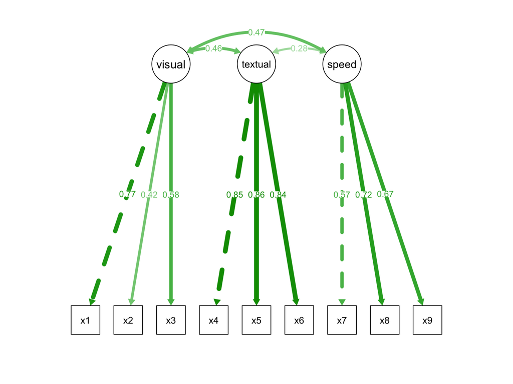

```r
if (requireNamespace("semPlot", quietly = TRUE)) {
  semPlot::semPaths(
    object = cfa_fit,
    what = "std",
    whatLabels = "std",
    layout = "tree",
    style = "ram",
    residuals = FALSE,
    intercepts = FALSE,
    edge.label.cex = 0.8,
    sizeLat = 8,
    sizeMan = 6,
    nCharNodes = 0
  )
} else {
  cat("Install the 'semPlot' package to display the latent-variable diagram.\n")
}
```

# 12 SEM and piecewise SEM

## 12.1 Two broad workflows

There are two broad SEM workflows.

1. **Covariance-based SEM** This is often fitted with `lavaan`. It models the covariance structure implied by the full model.
2. **Piecewise SEM** This fits each component as a separate regression and then combines the results.

Piecewise SEM is especially attractive in ecology because it can incorporate:

- linear models;
- GLMs;
- GLMMs;
- GAMs;
- random effects;
- non-normal responses.

The next document uses a piecewise-style workflow with ordinary regressions before showing how the same idea can be written in `lavaan`.

## 12.2 When might piecewise SEM be useful?

Piecewise SEM can be useful when:

- responses have different distributions;
- there are random effects;
- data are hierarchical;
- some pathways are best modelled using GLMs or GLMMs;
- sample sizes are moderate and the model is too complex for covariance-based SEM.

# 13 Exercise

## 13.1 Questions

1. Remove the direct path from temperature to birds. Does model fit change?
2. Add a direct path from rainfall to insects. Is it supported?
3. Which effect is larger: the direct effect of vegetation on birds or the indirect effect via insects?
4. Explain the difference between a direct and indirect effect using this example.

# 14 Exercise solution

The direct effect of vegetation on birds is the path:

$$\text{vegetation} \rightarrow \text{birds}$$

The indirect effect via insects is:

$$\text{vegetation} \rightarrow \text{insects} \rightarrow \text{birds}$$

In terms of path labels, the indirect effect is:

$$b_1 \times c_1$$

# 15 Summary

In this document, we introduced structural equation models.

Key points:

- SEM allows us to model networks of relationships;
- path models are built from linked regression equations;
- direct effects are single arrows;
- indirect effects pass through one or more mediating variables;
- total effects combine direct and indirect pathways;
- standardised coefficients help compare effect sizes;
- SEM does not prove causality without strong scientific assumptions;
- `lavaan` can fit both path models and latent-variable SEMs;
- piecewise SEM extends the same logic to GLMs, GLMMs and more complex ecological models.

# 16 Link to the next document

The next document moves from covariance-based SEM to a more practical, regression-based SEM workflow.

This is useful in ecology because many ecological models involve non-normal responses, hierarchical sampling designs and grouped observations.